# Theory #1

```r
library(car)
library(mosaic)
library(tidyverse)
library(DT)
library(pander)
library(readr)
library(plotly)
library(ggplot2)

Laptops <- read_csv("../Data/laptops.csv")
```

```r
Laptop <- Laptops %>%
  mutate(Price = Price_euros*1.12) %>%
  select(c("Company", "Price", "Inches", "Ram", "Weight")) %>%
  mutate(Weight = parse_number(Weight)) %>%
  mutate(Ram = parse_number(Ram))
```

Can you tell me what a residual is?? How about what SSE, SSR, and SSTO are?? And lastly, what does $R^2$ tell us about a regression? These are the questions we will be answering and exploring in this study. I will use two regression models show how the different values effect each other and how their meaning changes.

## Regressions

Below are two regressions that will be used as an explanation for the concepts we are studying.

#### Regression of Price by Inches

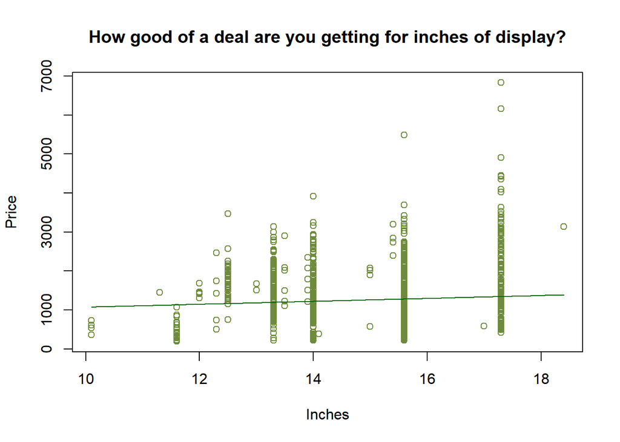

```r
plot(Price ~ Inches, data = Laptop, col = "darkolivegreen4", main = "How good of a deal are you getting for inches of display?")
curve(696.39+37.43*x, add = T, col = "darkgreen")
```

#### Regression of Price by Ram

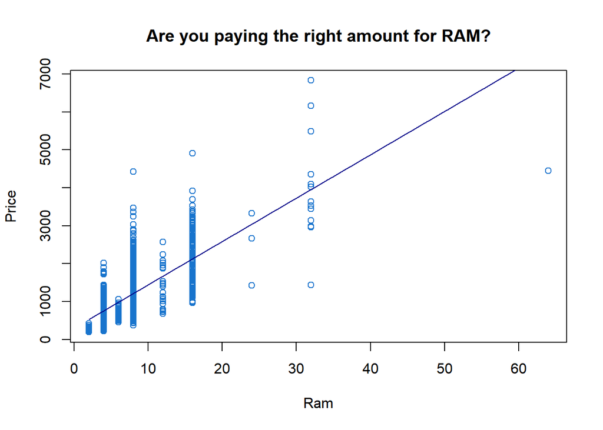

```r
plot(Price ~ Ram, data = Laptop, col = "dodgerblue3", main = "Are you paying the right amount for RAM?")
curve(299.594+114.401*x, add = T, col = "darkblue")
```

Here is a short summary of the values we will be looking at from each regression.

| Regression | SSE | SSR | SSTO | $R^2$ |
| --- | --- | --- | --- | --- |
| Inches | 794306462 | 3711410 | 798017871 | 0.004651 |
| Ram | 357464442 | 440553429 | 798017871 | 0.5521 |

## Residuals

Residuals are the difference between the observed $Y_i$ value and the predicted $\hat{Y_i}$ derived from the regression line. A residual is a value used to estimate the $\epsilon_i$ which is the difference between the $Y_i$ and the $E\{Y_i\}$.

A single residual provides a lot of information for an individual $i$! It tells us how that $Y_i$ differs from the average $Y$ explained by the regression line. For the above regressions, a residual tells a buyer if they spent more or less than the average amount based on how many inches the laptop is or how much RAM it has.

## SSTO, SSE, and SSR

| Variable | SSE | SSR | SSTO |
| --- | --- | --- | --- |
| What the acronym means | Sum of Squared Errors | Sum of Squares Regression | Total Sum of Squares |
| Definition | The difference between the observed Y and the regression line. | The difference between the regression line and average Y value. | The difference between the average Y vale and the observed Y. |

The best regression lines have a small SSE because that means that there is very little variation in the data. So in the above examples, RAM is a better fitting and explaining regression. Because SSE is smaller, it is telling us that the price of laptops doesn’t vary to much because of RAM.

Lets also look at the plot below and see how the sums work in the regression.

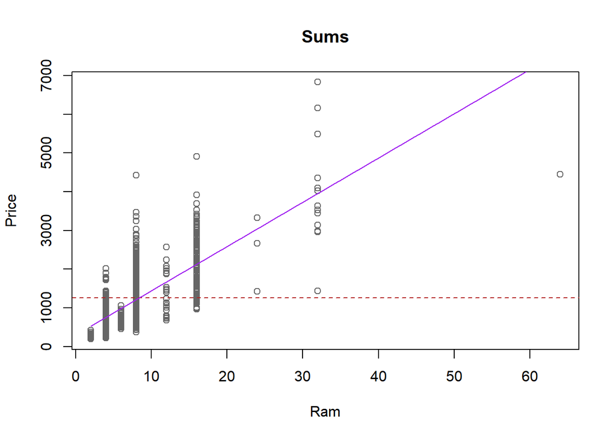

```r
#mean(Laptop$Price)
#1258.529

plot(Price ~ Ram, data = Laptop, col = "gray40", main = "Sums")
abline(h=1258.529, lty = 2, col= "firebrick")
curve(299.594+114.401*x, add = T, col = "Purple")
```

```r
#points(x-value, y-value, col="...", pch=...)
```

Also, `SSE + SSR = SSTO`!

## R-Squared

$R^2$ is the proportion of variation as explained by the regression line. We want $R^2$ to be large. The larger $R^2$ is the more variation it is accounting for in the data. We can think of it as a percentage of the data that we can explain.

$$R^2 = \frac{SSR}{SSTO} = 1 - \frac{SSE}{SSTO}$$

Overall, the most important thing to realize is that the residuals work into ever part of a regression problem!